# UC business Analytics R programming Guide

##### 2.1.5.7.4 Residual assessment

Keep in mind that logistic regression does not assume the residuals are normally distributed nor that the variance is constant. However, the deviance residual is useful for determining if individual points are not well fit by the model. Here we can fit the standardized deviance residuals to see how many exceed 3 standard deviations. First we extract several useful bits of model results with `augment` and then proceed to plot.

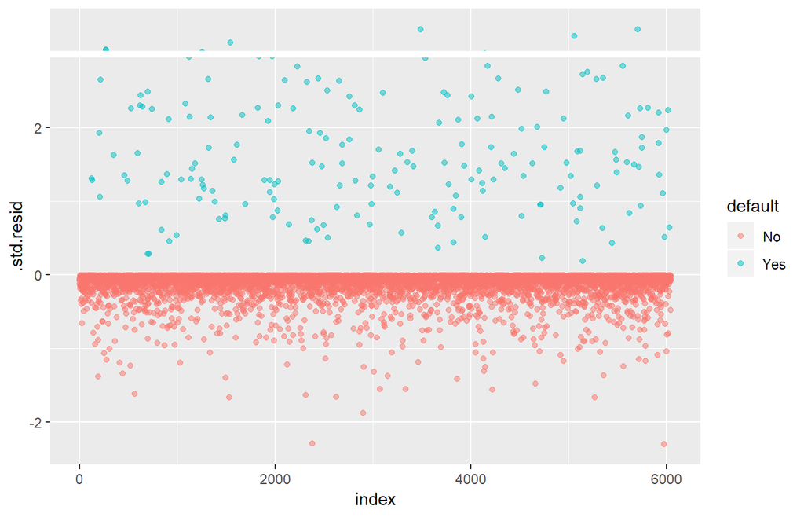

```r
model1_data <- augment(model1) %>%
  mutate(index = 1:n())

ggplot(model1_data, aes(index, .std.resid, col=default))+
  geom_point(alpha = .5)+
  geom_ref_line(h = 3)
```

Those standardized residuals that exceed 3 represent possible outliers and may deserve closer attention. We can filter for these residuals to get a closer look. We see that all these observations represent customers who defaulted with budgets that are much lower than the normal defaulters.

```r
model1_data %>%
  filter(abs(.std.resid) > 3)
```

```
## # A tibble: 8 x 10
##   default balance .fitted .se.fit .resid    .hat .sigma .cooksd .std.resid
##   <fct>     <dbl>   <dbl>   <dbl>  <dbl>   <dbl>  <dbl>   <dbl>      <dbl>
## 1 Yes       1119.   -4.66   0.175   3.06 2.84e-4  0.386  0.0151       3.06
## 2 Yes       1119.   -4.66   0.175   3.06 2.84e-4  0.386  0.0151       3.06
## 3 Yes       1135.   -4.57   0.171   3.03 2.97e-4  0.386  0.0144       3.03
## 4 Yes       1067.   -4.96   0.189   3.15 2.46e-4  0.386  0.0175       3.15
## 5 Yes        961.   -5.56   0.216   3.33 1.80e-4  0.385  0.0232       3.33
## 6 Yes       1144.   -4.52   0.169   3.01 3.03e-4  0.386  0.0140       3.01
## 7 Yes       1013.   -5.26   0.203   3.25 2.11e-4  0.385  0.0203       3.25
## 8 Yes        962.   -5.55   0.216   3.33 1.80e-4  0.385  0.0232       3.33
## # ... with 1 more variable: index <int>
```

Similar to linear regression we can also identify influential observations with Cook’s distance values. Here we identify the top 5 largest values.

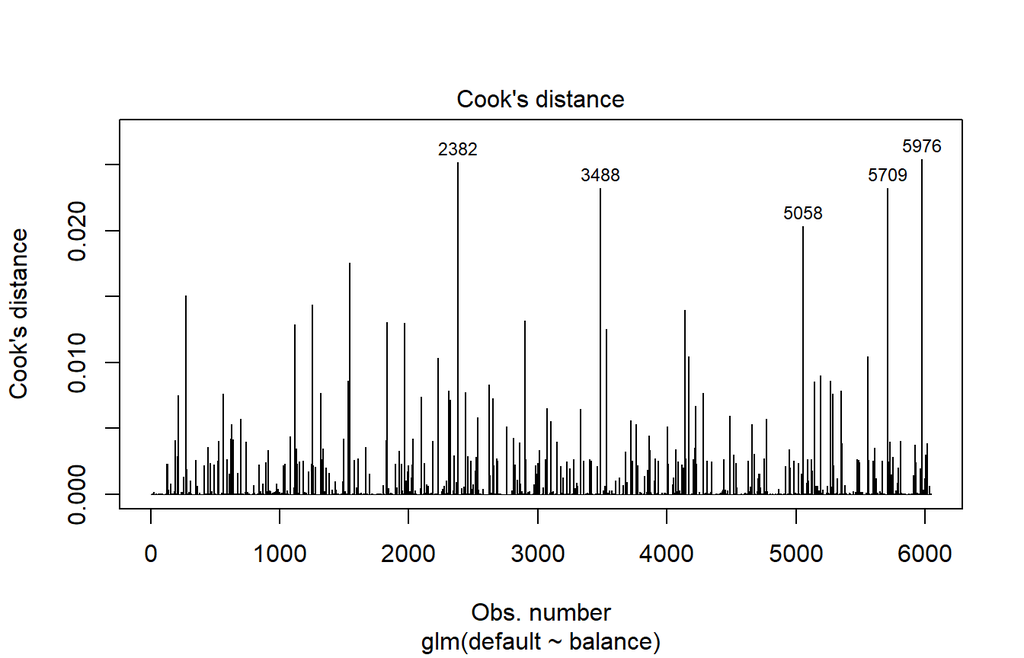

```r
plot(model1, which = 4, id.n = 5)
```

And we can investigate these further as well. Here we see that the top five influential points include:

- hose customers who defaulted with very low balances and
- two customers who did not default, yet had balances over $2,000

This means if we were to remove these observations (not recommended), the shape, location, and confidence interval of our logistic regression S-curve would likely shift.

```r
model1_data %>%
  top_n(5, .cooksd)
```

```
## # A tibble: 5 x 10
##   default balance .fitted .se.fit .resid    .hat .sigma .cooksd .std.resid
##   <fct>     <dbl>   <dbl>   <dbl>  <dbl>   <dbl>  <dbl>   <dbl>      <dbl>
## 1 No        2388.    2.53   0.241  -2.28 3.98e-3  0.387  0.0252      -2.29
## 2 Yes        961.   -5.56   0.216   3.33 1.80e-4  0.385  0.0232       3.33
## 3 Yes       1013.   -5.26   0.203   3.25 2.11e-4  0.385  0.0203       3.25
## 4 Yes        962.   -5.55   0.216   3.33 1.80e-4  0.385  0.0232       3.33
## 5 No        2391.    2.55   0.242  -2.29 3.95e-3  0.387  0.0254      -2.30
## # ... with 1 more variable: index <int>
```

#### 2.1.5.8 Validation of predicted values

##### 2.1.5.8.1 Classification rate

```r
test.predicted.m1 <- predict(model1, newdata = test, type = "response")
test.predicted.m2 <- predict(model2, newdata = test, type = "response")
test.predicted.m3 <- predict(model3, newdata = test, type = "response")
```

Now we can compare the predicted target variable versus the observed values for each model and see which performs the best. We can start by using the confusion matrix, which is a table that describes the classification performance for each model on the test data. Each quadrant of the table has an important meaning. In this case the “No” and “Yes” in the rows represent whether customers defaulted or not. The “FALSE” and “TRUE” in the columns represent whether we predicted customers to default or not.

- **true positives** (Bottom-right quadrant): these are cases in which we predicted the customer would default and they did.
- **true negatives** (Top-left quadrant): We predicted no default, and the customer did not default.
- **false positives** (Top-right quadrant): We predicted yes, but they didn’t actually default. (Also known as a “Type I error.”)
- **false negatives** (Bottom-left): We predicted no, but they did default. (Also known as a “Type II error.”)

The results show that `model1` and `model3` are very similar. 96% of the predicted observations are true negatives and about 1% are true positives. Both models have a type II error of less than 3% in which the model predicts the customer will not default but they actually did. And both models have a type I error of less than 1% in which the models predicts the customer will default but they never did. `model2` results are notably different; this model accurately predicts the non-defaulters (a result of 97% of the data being non-defaulters) but never actually predicts those customers that default!

```r
list(
  model1 = table(test$default, test.predicted.m1 > 0.5) %>% prop.table() %>% round(3),
  model2 = table(test$default, test.predicted.m2 > 0.5) %>% prop.table() %>% round(3),
  model3 = table(test$default, test.predicted.m3 > 0.5) %>% prop.table() %>% round(3))
```

```
## $model1
##
##       FALSE  TRUE
##   No  0.962 0.003
##   Yes 0.025 0.010
##
## $model2
##
##       FALSE
##   No  0.965
##   Yes 0.035
##
## $model3
##
##       FALSE  TRUE
##   No  0.963 0.003
##   Yes 0.026 0.009
```

We also want to understand the misclassification (aka *error*) rates (or we could flip this for the accuracy rates). . We don’t see much improvement between models 1 and 3 and although model 2 has a low error rate don’t forget that it never accurately predicts customers that actually default.

```r
test %>%
  mutate(m1.pred = ifelse(test.predicted.m1 > 0.5, "Yes", "No"),
         m2.pred = ifelse(test.predicted.m2 > 0.5, "Yes", "No"),
         m3.pred = ifelse(test.predicted.m3 > 0.5, "Yes", "No")) %>%
  summarise(m1.error = mean(default != m1.pred),
            m2.error = mean(default != m2.pred),
            m3.error = mean(default != m3.pred))
```

```
## # A tibble: 1 x 3
##   m1.error m2.error m3.error
##      <dbl>    <dbl>    <dbl>
## 1   0.0278   0.0349   0.0281
## # A tibble: 1 × 3
##     m1.error   m2.error   m3.error
##        <dbl>      <dbl>      <dbl>
## 1 0.02782697 0.03491019 0.02807994
```

We can gain some additional insights by looking at the raw values (not percentages) in our confusion matrix. Lets look at model 1 to illustrate. We see that there are a total of $98+40=138$ customers that defaulted. Of the total defaults, $98/138=71%$ were not predicted. Alternatively, we could say that only $40/138=29$ of default occurrences were predicted - this is known as the the precision (also known as sensitivity) of our model. So while the overall error rate is low, the precision rate is also low, which is not good!

```r
table(test$default, test.predicted.m1>0.5)
```

```
##
##       FALSE TRUE
##   No   3803   12
##   Yes    98   40
```

With classification models you will also here the terms *sensitivity* and *specificity* when characterizing the performance of the model. As mentioned above sensitivity is synonymous to precision. However, the specificity is the percentage of non-defaulters that are correctly identified, here $1 -12/(3803+12) = 99.6%$ (the accuracy here is largely driven by the fact that 97% of the observations in our data are non-defaulters). The importance between *sensitivityy* and *specificity* is dependent on context. In this case, a credit card company is likely to be more concerned with sensititivy since they want to reduce their risk. Therefore, they may be more concerned with tuning a model so that their *sensititivy*/*precision* is improved.

The receiving operating characteristic (ROC) is a visual measure of classifier performance. Using the proportion of positive data points that are correctly considered as positive and the proportion of negative data points that are mistakenly considered as positive, we generate a graphic that shows the trade off between the rate at which you can correctly predict something with the rate of incorrectly predicting something. Ultimately, we’re concerned about the area under the ROC curve, or AUC. That metric ranges from 0.50 to 1.00, and values above 0.80 indicate that the model does a good job in discriminating between the two categories which comprise our target variable. We can compare the ROC and AUC for model’s 1 and 2, which show a strong difference in performance. We definitely want our ROC plots to look more like model 1’s (left) rather than model 2’s (right)!

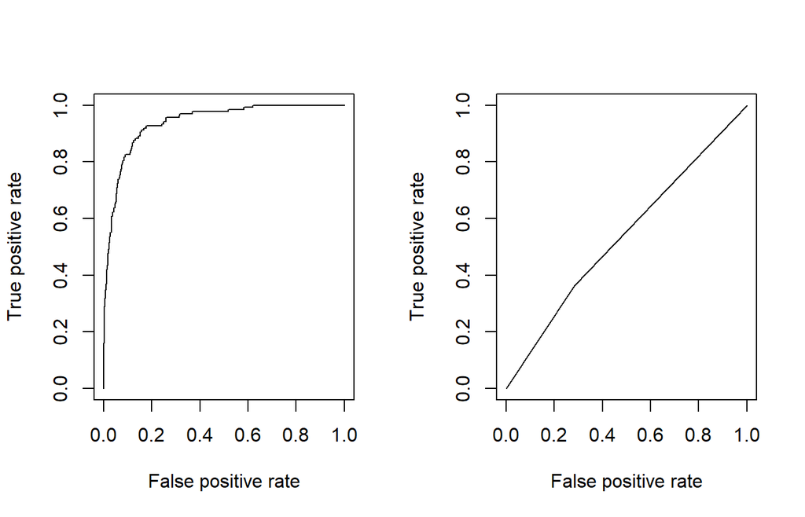

```r
library(ROCR)

par(mfrow=c(1, 2))

prediction(test.predicted.m1, test$default) %>%
  performance(measure = "tpr", x.measure = "fpr") %>%
  plot()

prediction(test.predicted.m2, test$default) %>%
  performance(measure = "tpr", x.measure = "fpr") %>%
  plot()
```

And to compute the AUC numerically we can use the following. Remember, AUC will range from .50 - 1.00. Thus, model 2 is a very poor classifying model while model 1 is a very good classying model.

```r
# model1 AUC
prediction(test.predicted.m1, test$default) %>%
  performance(measure = "auc") %>%
  .@y.values
## [[1]]
## [1] 0.939932
## [[1]]
## [1] 0.939932

# model 2 AUC
prediction(test.predicted.m2, test$default) %>%
  performance(measure = "auc") %>%
  .@y.values
## [[1]]
## [1] 0.5386955
## [[1]]
## [1] 0.5386955
```

We can continue to “tune” our models to improve these classification rates. If you can improve your AUC and ROC curves (which means you are improving the classification accuracy rates) you are creating *“lift”*, meaning you are lifting the classification accuracy.

#### 2.1.5.9 Additional resources

This will get you up and running with logistic regression. Keep in mind that there is a lot more you can dig into so the following resources will help you learn more:

An Introduction to Statistical Learning Applied Predictive Modeling Elements of Statistical Learning

### 2.1.6 Regularized regression

As discussed, linear regression is a simple and fundamental approach for supervised learning. Moreover, when the assumption required by OLS are met, the coefficients produced by OLS are unbiased and, of all unbiased linear techniques, have the lowest variance. However, in today’s world, data sets being analyzed typically have a large amount of features. As the number of features grow, our OLS assumptions typically break down and our models often overfit (aka have high variance) to the training sample, causing our out of sample error to increase. Regularization methods provide a means to control our regression coefficients, which can reduce the variance and decrease our of sample error.

#### 2.1.6.1 tl;dr

This tutorial serves as an introduction to regularized and covers:

1. Replication requirements: What you’ll need to reproduce the analysis in this tutorial.
2. Why regularize: A closer look at why regularization can improve upon ordinary least squares regression.
3. Ridge regression: Regularizing coefficients but keeping all features.
4. Lasso regression: Regularizing coefficients to perform feature selection.
5. Elastic nets: Combining Ridge and Lasso regularization. Predicting: Once you’ve found your optimal model, predict on a new data set.
6. Other package implementations: Implementing regularization with other popular packages.
7. Learning more: Where to go from here.

#### 2.1.6.2 Replication Requirements:

This tutorial leverages the following packags. Most of these packages are playing a supporting role while the main emphasis will be on the `glmnet` package.

```r
library(rsample)  # data splitting
library(glmnet)   # implementing regularized regression approaches
library(dplyr)    # basic data manipulation procedures
library(ggplot2)  # plotting
```

To illustrate various regularization concepts, we will use the `Ames` Housing data that has been included in the `AmesHousing` package.

```r
# Create training (70%) and test (30%) sets for the AmesHousing::make_ames() data.
# Use set.seed for reproducibility

set.seed(123)

ames_split <- initial_split(AmesHousing::make_ames(), prop = .7, strata = "Sale_Price")
ames_train <- training(ames_split)
ames_test  <- testing(ames_split)
```

#### 2.1.6.3 Why regularize

More formally, this objective function is written as:
$$minimize [{SSE = \Sigma_{i=1}^n (y_i-\hat{}y_i)^2}]$$

The OLS objective function performs quite well when our data align to the key assumptions of OLS regression:

- Linear relationship
- Multivariate normality
- No autocorrelation
- Homoscedastic (constant variance in residuals)
- There are more observations (n) than features

However, for many real-life data sets we have very *wide* data, meaning we have a large number of features (*p*) that we believe are informative in predicting some outcome. As *p* increases, we can quickly violate some of the OLS assumptions and we require alternative approaches to provide predictive analytic solutions. Specifically, as *p* increases there are three main issues we most commonly run into:

**1. Multicollinearty**

As *p* increases we are more likely to capture multiple features that have some multicollinearity. When multicollinearity exists, we often see high variability in our coefficient terms. For example, in our Ames data, `Gr_Liv_Area` and `TotRms_AbvGrd` are two variables that have a correlation of 0.801 and both variables are strongly correlated to our response variable (`Sale_Price`). When we fit a model with both these variables we get a positive coefficient for `Gr_Liv_Area` but a negative coefficient for `TotRms_AbvGrd`, suggesting one has a positive impact to `Sale_Price` and the other a negative impact.

```r
# fit with two strongly correlated variables
lm(Sale_Price ~ Gr_Liv_Area + TotRms_AbvGrd, data = ames_train)
```

```
##
## Call:
## lm(formula = Sale_Price ~ Gr_Liv_Area + TotRms_AbvGrd, data = ames_train)
##
## Coefficients:
##   (Intercept)    Gr_Liv_Area  TotRms_AbvGrd
##       49953.6          137.3       -11788.2
##
## Call:
## lm(formula = Sale_Price ~ Gr_Liv_Area + TotRms_AbvGrd, data = ames_train)
##
## Coefficients:
##   (Intercept)    Gr_Liv_Area  TotRms_AbvGrd
##       49953.6          137.3       -11788.2
```

However, if we refit the model with each variable independently, they both show a positive impact. However, the `Gr_Liv_Area` effect is now smaller and the `TotRms_AbvGrd` is positive with a much larger magnitude.

```r
# fit with just Gr_Liv_Area
lm(Sale_Price ~ Gr_Liv_Area, data = ames_train)
```

```
##
## Call:
## lm(formula = Sale_Price ~ Gr_Liv_Area, data = ames_train)
##
## Coefficients:
## (Intercept)  Gr_Liv_Area
##       17797          108
##
## Call:
## lm(formula = Sale_Price ~ Gr_Liv_Area, data = ames_train)
##
## Coefficients:
## (Intercept)  Gr_Liv_Area
##       17797          108
```

```r
# fit with just TotRms_Area
lm(Sale_Price ~ TotRms_AbvGrd, data = ames_train)
```

```
##
## Call:
## lm(formula = Sale_Price ~ TotRms_AbvGrd, data = ames_train)
##
## Coefficients:
##   (Intercept)  TotRms_AbvGrd
##         26820          23731
##
## Call:
## lm(formula = Sale_Price ~ TotRms_AbvGrd, data = ames_train)
##
## Coefficients:
##   (Intercept)  TotRms_AbvGrd
##         26820          23731
```

This is a common result when collinearity exists. Coefficients for correlated features become over-inflated and can fluctuate significantly. One consequence of these large fluctuations in the coefficient terms is overfitting, which means we have high variance in the bias-variance tradeoff space. Although an analyst can use tools such as variance inflaction factors (Myers, 1994) to identify and remove those strongly correlated variables, it is not always clear which variable(s) to remove. Nor do we always wish to remove variables as this may be removing signal in our data.

**2. Insufficient solution**

When the number of features exceed the number of observations ($p>n$), the OLS solution matrix is *not* invertible. This causes significant issues because it means: (1) The least-squares estimates are not unique. In fact, there are an infinite set of solutions available and most of these solutions overfit the data. (2) In many instances the result will be computationally infeasible.

Consequently, to resolve this issue an analyst can remove variables until $p < n$ and then fit an OLS regression model. Although an analyst can use pre-processing tools to guide this manual approach (Kuhn & Johnson, 2013, pp. 43-47), it can be cumbersome and prone to errors.

**3. Interpretability**

With a large number of features, we often would like to identify a smaller subset of these features that exhibit the strongest effects. In essence, we sometimes prefer techniques that provide feature selection. One approach to this is called *hard threshholding* feature selection, which can be performed with linear model selection approaches. However, model selection approaches can be computationally inefficient, do not scale well, and they simply assume a feature as in or out. We may wish to use a *soft threshholding* approach that slowly pushes a feature’s effect towards zero. As will be demonstrated, this can provide additional understanding regarding predictive signals.

**Regulaized regression**

When we experience these concerns, one alternative to OLS regression is to use regularized regression (also commonly referred to as *penalized* models or *shrinkage* methods) to control the parameter estimates. Regularized regression puts contraints on the magnitude of the coefficients and will progressively shrink them towards zero. This constraint helps to reduce the magnitude and fluctuations of the coefficients and will reduce the variance of our model.

The objective function of regulaized regression model is very similar to OLS regression; however, we add a penalty paramter (`P`)

$$minimize(SSE + P)$$

There are two main penalty parameters, which we will see shortly, but they both have a similarr effect. They constrain the size of the coefficients such that the only way the coefficients can increase is if we experience a comparable decrease in the sum of squared errors (SSE). Next, we’ll explore the most common approaches to incorporate regularization.

#### 2.1.6.4 Ridge

Ridge regression [(Hoerl, 1970](https://www.tandfonline.com/doi/abs/10.1080/00401706.1970.10488634)) controls the coefficients by adding $\lambda \Sigma_{j=1}^p \beta_j^2$ to the objective function. This penalty parameter is also referred to as “$L_2$” as it signifies a second-order penlty being used on the coefficients.

$$minimize (SSE + \lambda \Sigma_{j=1}^p \beta_j^2)$$

##### 2.1.6.4.1 Implementation

To implement Ridge regression, we will focus on the `glmnet` package (implementation in other packages are illustrated [below](http://uc-r.github.io/regularized_regression#other)). `glmnet` does not use the formula method (`y ~ x`) so prior to modeling we need to create our feature and target set. Furthermore, we use the `model.matrix` function on our feature set, which will automatically dummy encode qualitative variables (see `Matrix::sparse.model.matrix` for increased efficiency on large dimension data). We also log transform our response variable due to its skeweness.

```r
# Create training and testing feature model matrices and response vectors.
# we use model.matrix(...)[, -1] to discard the intercept
ames_train_x <- model.matrix(Sale_Price ~ ., ames_train)[, -1]
ames_train_y <- log(ames_train$Sale_Price)

ames_test_x <- model.matrix(Sale_Price ~ ., ames_test)[, -1]
ames_test_y <- log(ames_test$Sale_Price)

# What is the dimension of of your feature matrix?
dim(ames_train_x)
```

```
## [1] 2054  307
## [1] 2054  307
```

To apply a ridge model we can use the glmnet::glmnet function. The alpha parameter tells glmnet to perform a ridge (`alpha = 0`), lasso (`alpha = 1`), or elastic net ($0 < alpha < 1$) model. Behind the scenes, `glmnet` is doing two things that you should be awre of:

1. It is essential that predictor variables are standardized when performing regularized regression. `glmnet` performs this for you. If you standardize your predictors prior to `glmnet` you can turn this argument off with `standardize = FALSE`.
2. `glmnet` will perform ridge models across a wide range of $\lambda$ parameters, which are illustrated in the figure below.

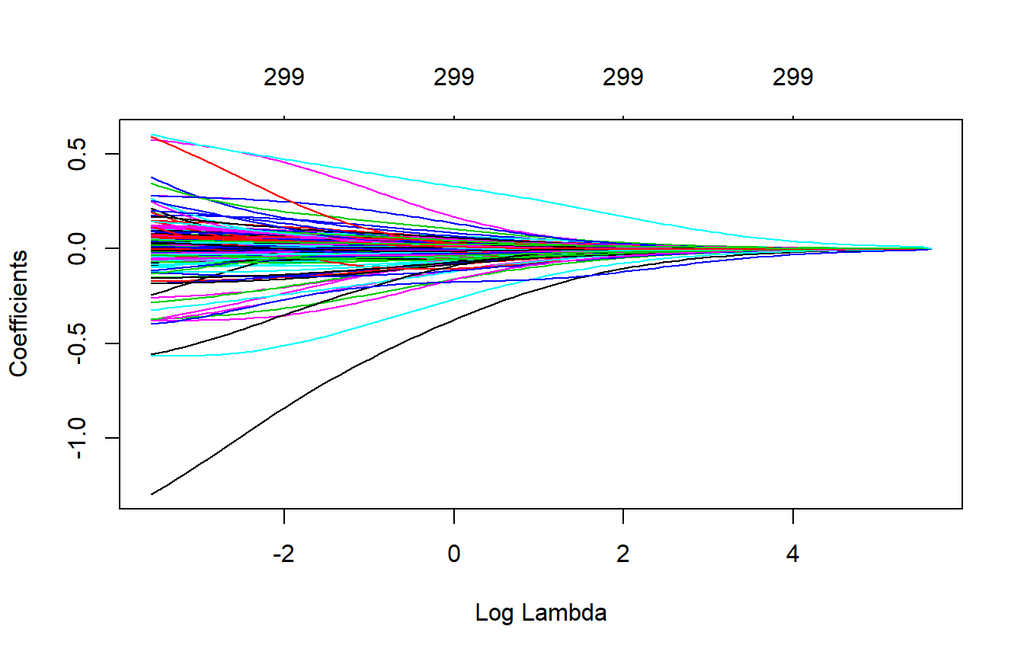

```r
# apply ridge regression to ames data
library(glmnet)
ames_ridge <- glmnet(
  x = ames_train_x,
  y = ames_train_y,
  alpha = 0
)

plot(ames_ridge, xvar="lambda")
```

In fact, we can see the exact $\lambda$ values applied with `ames_ridge$lambda`. Although you can specify your own $\lambda$ values, by default `glmnet` applies 100 $\lambda$ values that are derived. Majority of the time you will have little need to adjust the default $\lambda$ values.

We can also directly access the coefficients for a model using `coef. glmnet` stores all the coefficients for each model in order of largest to smallest $\lambda$. Due to the number of features, here I just peak at thebcoefficients for the `Gr_Liv_Area` and `TotRms_abvGrd` features for the largest $\lambda$ (279.1035) and smallest $\lambda$ (0.02791035). You can see how the largest $\lambda$ value has pushed these coefficients to nearly 0.

```r
# lambdas applied to penalty parameter
ames_ridge$lambda %>% head()
```

```
## [1] 279.1035 254.3087 231.7166 211.1316 192.3752 175.2851
## [1] 279.1035 254.3087 231.7166 211.1316 192.3752 175.2851
```

```r
# coefficients for the largest and smallest lambda parameters
coef(ames_ridge)[c("Gr_Liv_Area", "TotRms_AbvGrd"), 100]
```

```
##   Gr_Liv_Area TotRms_AbvGrd
##  0.0001004011  0.0096383231
##   Gr_Liv_Area TotRms_AbvGrd
##  0.0001004011  0.0096383231
```

```r
coef(ames_ridge)[c("Gr_Liv_Area", "TotRms_AbvGrd"), 1]
```

```
##   Gr_Liv_Area TotRms_AbvGrd
##  5.551202e-40  1.236184e-37
##   Gr_Liv_Area TotRms_AbvGrd
##  5.551202e-40  1.236184e-37
```

However, at this point, we do not understand how much improvement we are experiencing in our model.

**Tuning**

Recall tht $\lambda$ is a tuning parameter that helps to control our model frok overfitting to the training data. However, to identify the optimal $\lambda$ value we need to perform [cross validation](http://uc-r.github.io/resampling_methods) (CV). `cv.glmnet` provides a built-in option to perform k-fold CV, and by default, performs 10-fold CV.

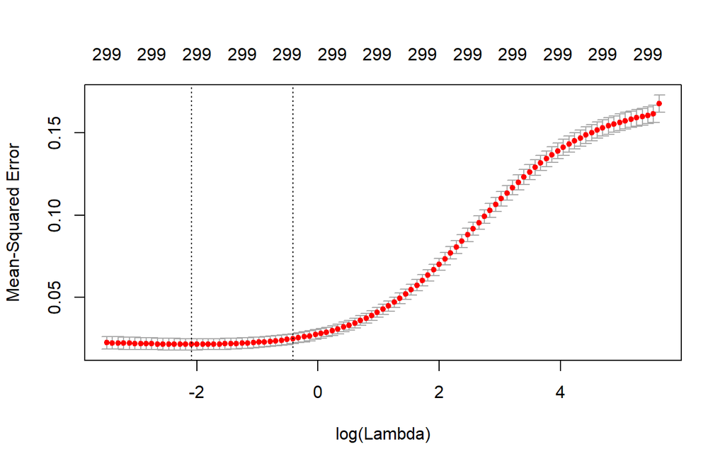

```r
# Apply CV Ridge regression to ames data
ames_ridge <- cv.glmnet(
  x = ames_train_x,
  y = ames_train_y,
  alpha = 0
)

# plot results
plot(ames_ridge)
```

Our plot outputs above illustrates the 10-fold CV mean squared error(MSE) across the $\lambda$ values. It illustrates that we do not see substantial improvement; however, as we constrain our coefficients with $log(\lambda)>0$ penalty, the MSE rises considerably.

The numbers at the top of the plot (299) just refer to the number of variables in the model. Ridge regression does not force any variable exactly zero so all features will remain in the model (we will see this change with `lasso` and `elastic nets`).

```r
ames_ridge$cvm %>% min() #minimum MSE
```

```
## [1] 0.02147691
```

```r
ames_ridge$lambda.min # lambda for this min MSE
```

```
## [1] 0.1236602
```

```r
ames_ridge$cvm[ames_ridge$lambda == ames_ridge$lambda.1se] # 1st st.error
```

```
## [1] 0.02488411
```

```r
ames_ridge$lambda.1se  # lambda for this MSE
```

```
## [1] 0.6599372
```

The advantage of identifying the $\lambda$ with an MSE within one standard error becomes more obvious with the lasso and elastic net models. However, for now we can assess this visually. Here we plot the coefficients across the $\lambda$ values and the dashed red line represents the largest $\lambda$ that falls within oe standard error of the minimum MSE. This shows you how much we can constrain the coefficients while still maximizing predictive accuracy.

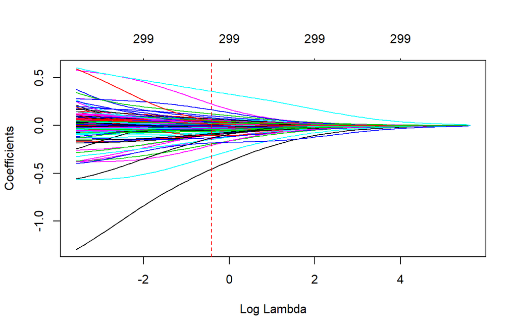

```r
ames_ridge_min <- glmnet(
  x = ames_train_x,
  y = ames_train_y,
  alpha = 0
)

plot(ames_ridge_min, xvar = "lambda")
abline(v = log(ames_ridge$lambda.1se), col = "red", lty = "dashed")
```

**Advantage & Disdvantage**

In essence, the ridge regression model has pushed many of the correlated features towards each other rather than allowing for one to be wildly positive and the other wildly negative. Furthermore, many of the non-important features have been pushed closer to zero. This means we have reduced the noise in our data, which provides us more clarity in identifying the true signals in our model.

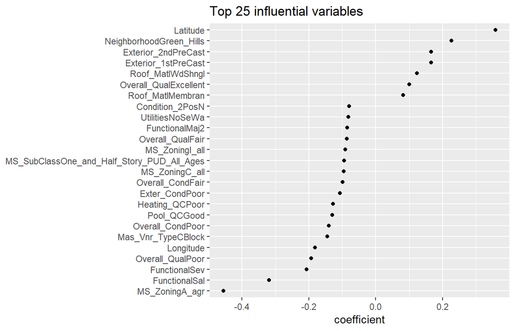

```r
coef(ames_ridge, s = "lambda.1se") %>%
  broom::tidy() %>%
  filter(row != "(Intercept)") %>%
  top_n(25, wt = abs(value)) %>%
  ggplot(aes(value, reorder(row, value)))+
  geom_point()+
  ggtitle("Top 25 influential variables")+
  xlab("coefficient")+
  ylab(NULL)
```

However, **a ridge model will retain all variables**. Therefore, a ridge model is good if you believe there is a need to retain all features in your model yet reduce the noise that less influential variables may create and minimize multicollinearity. However, a ridge model does not perform feature selection. If greater interpretation is necessary where you need to reduce the signal in your data to a smaller subset then a lasso model may be preferable.

#### 2.1.6.5 LASSO

The *least absolute shrinkage and selection operator (lasso)* model ([Tibshirani, 1996](http://www.jstor.org/stable/2346178?seq=1#page_scan_tab_contents)) is an alternative to ridge regression that has a small modification to the penalty in the objective function. Rather than the $L_2$ penalty we use the following $L_1$ penalty $\lambda \Sigma_{j=1}^p|\beta_j|$ in the objective function

$$minimize (SSE + \lambda \Sigma_{j=1}^p|\beta_j|)$$

**Implementation**

Implementing lasso follows the same logic as implementing the ridge model, we just need to switch `alpha=1` within `glmnet`.

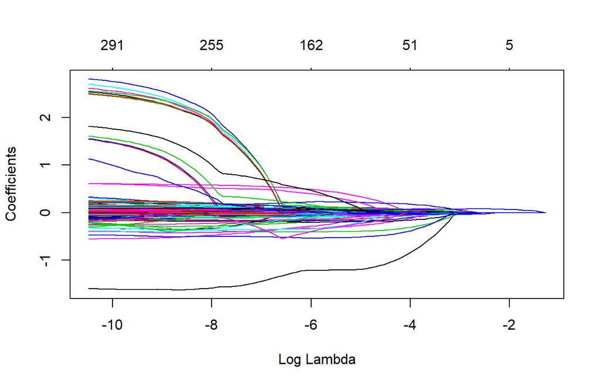

```r
## apply lasso regression to ames data

ames_lasso <- glmnet(
  x = ames_train_x,
  y = ames_train_y,
  alpha = 1
)

plot(ames_lasso, xvar = "lambda")
```

Our output illustrates a quick drop in the number of features retained in the lasso model as $log(\lambda)$-> -6. In fact, we see several features that had very large coefficients for the OLS model (when $log(\lambda)=-10 -> \lambda=0$. As before, these features are likely highly correlated with other features in the data, causing their coefficients to be excessively large. As we constrain our model, these noisy features are pushed to zero.

However, similar to the Ridge regression section, we need to perform CV to determine when the right value is for $\lambda$.

**Tuning**

To perform CV we use the same approach as we did in the ridge regression tuning section, but change our `alpha = 1`. We see that we can minimize our MSE by applying approximately $-6 < log(\lambda) < -4$ Not only does this minimize our MSE but it also reduces the number of features to $156 > p > 58$

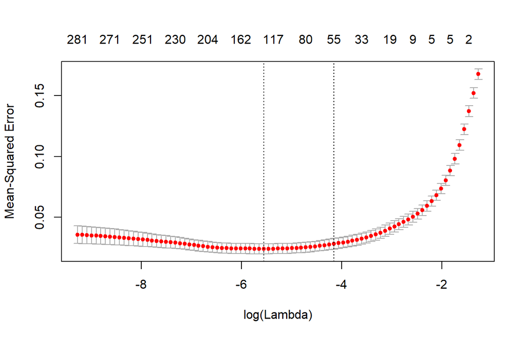

```r
# Apply CV Ridge regression to ames data
ames_lasso <- cv.glmnet(
  x = ames_train_x,
  y = ames_train_y,
  alpha = 1
)
# plot results
plot(ames_lasso)
```

As before, we can extract our minimum and one standard error MSE and $\λ$ values.

```r
min(ames_lasso$cvm)       # minimum MSE
```

```
## [1] 0.02411134
## [1] 0.02275227
```

```r
ames_lasso$lambda.min     # lambda for this min MSE
```

```
## [1] 0.003865266
## [1] 0.003521887
```

```r
ames_lasso$cvm[ames_lasso$lambda == ames_lasso$lambda.1se]  # 1 st.error of min MSE
```

```
## [1] 0.02819356
## [1] 0.02562055
```

```r
ames_lasso$lambda.1se  # lambda for this MSE
```

```
## [1] 0.01560415
## [1] 0.01180396
```

Now the advantage of identifying the $\lambda$ with an MSE within one standard error becomes more obvious. If we use the $\lambda$ that derives the minimum MSE we can reduce our feature set from 307 down to less than 160. However, there will be some variability with this MSE and we can reasonably assume that we can achieve a similar MSE with a slightly more constrained model that uses only 63 features. If describing and interpreting the predictors is an important outcome of your analysis, this may significantly aid your endeavor.

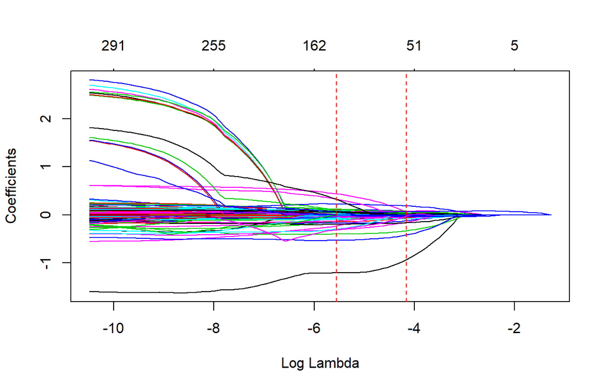

```r
ames_lasso_min <-  glmnet(
  x = ames_train_x,
  y = ames_train_y,
  alpha = 1
)

plot(ames_lasso_min, xvar = "lambda")
abline(v = log(ames_lasso$lambda.min), col = "red", lty = "dashed")
abline(v = log(ames_lasso$lambda.1se), col = "red", lty = "dashed")
```

**Advantage & Disadvantage**

Similar to ridge, the lasso pushes many of the collinear features towards each other rather than allowing for one to be wildly positive and the other wildly negative. However, unlike ridge, the lasso will actually push coefficients to zero and perform feature selection. This simplifies and automates the process of identifying those feature most influential to predictive accuracy.

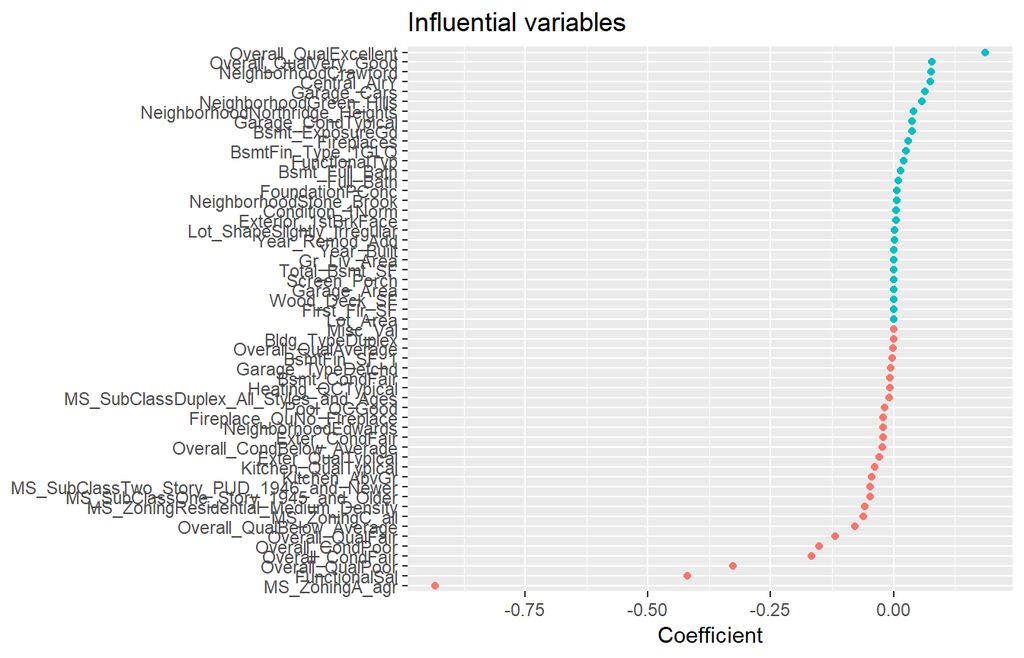

```r
coef(ames_lasso, s = "lambda.1se") %>%
  broom::tidy() %>%
  filter(row != "(Intercept)") %>%
  ggplot(aes(value, reorder(row, value), color = value >0))+
  geom_point(show.legend = FALSE)+
  ggtitle("Influential variables")+
  xlab("Coefficient")+
  ylab(NULL)
```

However, often when we remove features we sacrifice accuracy. Consequently, to gain the refined clarity and simplicity that lasso provides, we sometimes reduce the level of accuracy. Typically we do not see large differences in the minimum errors between the two. So practically, this may not be significant but if you are purely competing on minimizing error (i.e. Kaggle competitions) this may make all the difference!

```r
# minimum Ridge MSE
min(ames_ridge$cvm)
```

```
## [1] 0.02147691
## [1] 0.02147691
```

```r
# minimum Lasso MSE
min(ames_lasso$cvm)
```

```
## [1] 0.02411134
## [1] 0.02275227
```

#### 2.1.6.6 Elastic Nets

A generalization of the ridge and lasso models is the elastic net (Zou and Hastie, 2005), which combines the two penalties.

$$minimize(SSE + \lambda_1\Sigma_{j=1}^p \beta_j^2 + \lambda_2\Sigma_{j=1}^p |\beta_j|)$$

Although lasso models perform feature selection, a result of their penalty parameter is that typically when two strongly correlated features are pushed towards zero, one may be pushed fully to zero while the other remains in the model. Furthermore, the process of one being in and one being out is not very systematic. In contrast, the ridge regression penalty is a little more effective in systematically reducing correlated features together. Consequently, the advantage of the elastic net model is that it enables effective regularization via the ridge penalty with the feature selection characteristics of the lasso penalty.

**Implementation**

We implement an elastic net the same way as the ridge and lasso models, which are controlled by the alpha parameter. Any alpha value between 0-1 will perform an elastic net. When alpha = 0.5 we perform an equal combination of penalties whereas `alpha` $→0$ will have a heavier ridge penalty applied and `alpha` $→1$ will have a heavier lasso penalty.

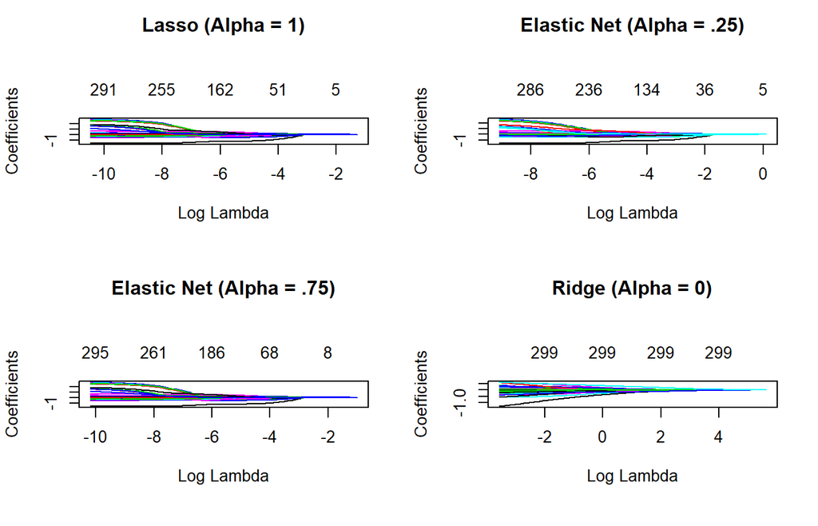

```r
library(glmnet)
lasso    <- glmnet(ames_train_x, ames_train_y, alpha = 1.0)
elastic1 <- glmnet(ames_train_x, ames_train_y, alpha = 0.25)
elastic2 <- glmnet(ames_train_x, ames_train_y, alpha = 0.75)
ridge    <- glmnet(ames_train_x, ames_train_y, alpha = 0.0)

par(mfrow = c(2, 2), mar = c(6, 4, 6, 2) + 0.1)
plot(lasso, xvar = "lambda", main = "Lasso (Alpha = 1)\n\n\n")
plot(elastic1, xvar = "lambda", main = "Elastic Net (Alpha = .25)\n\n\n")
plot(elastic2, xvar = "lambda", main = "Elastic Net (Alpha = .75)\n\n\n")
plot(ridge, xvar = "lambda", main = "Ridge (Alpha = 0)\n\n\n")
```

**Tuning**

In ridge and lasso models $\lambda$ is our primary tuning parameter. However, with elastic nets, we want to tune the $\lambda$ and the `alpha` parameters. To set up our tuning, we create a common `fold_id`, which just allows us to apply the same CV folds to each model.

We then create a tuning grid that searches across a range of `alpha`s from 0-1, and empty columns where we will dump our model results into.

```r
# maintain the same folds across all models
fold_id <- sample(1:10, size = length(ames_train_y), replace=TRUE)

# search across a range of alphas
tuning_grid <- tibble::tibble(
  alpha      = seq(0, 1, by = .1),
  mse_min    = NA,
  mse_1se    = NA,
  lambda_min = NA,
  lambda_1se = NA
)
```

Now we can iterate over each alpha value, apply a CV elastic net, and extract the minimum and one standard error MSE values and their respective $\lambda$ values.

```r
for(i in seq_along(tuning_grid$alpha)) {

  # fit CV model for each alpha value
  fit <- cv.glmnet(ames_train_x, ames_train_y, alpha = tuning_grid$alpha[i], foldid = fold_id)

  # extract MSE and lambda values
  tuning_grid$mse_min[i]    <- fit$cvm[fit$lambda == fit$lambda.min]
  tuning_grid$mse_1se[i]    <- fit$cvm[fit$lambda == fit$lambda.1se]
  tuning_grid$lambda_min[i] <- fit$lambda.min
  tuning_grid$lambda_1se[i] <- fit$lambda.1se
}

tuning_grid
```

```
## # A tibble: 11 x 5
##    alpha mse_min mse_1se lambda_min lambda_1se
##    <dbl>   <dbl>   <dbl>      <dbl>      <dbl>
##  1   0    0.0230  0.0267    0.179       0.795
##  2   0.1  0.0237  0.0285    0.0387      0.156
##  3   0.2  0.0241  0.0289    0.0193      0.0856
##  4   0.3  0.0243  0.0295    0.0129      0.0627
##  5   0.4  0.0245  0.0295    0.00966     0.0470
##  6   0.5  0.0246  0.0295    0.00773     0.0376
##  7   0.6  0.0247  0.0301    0.00644     0.0344
##  8   0.7  0.0247  0.0302    0.00552     0.0295
##  9   0.8  0.0247  0.0302    0.00483     0.0258
## 10   0.9  0.0247  0.0302    0.00429     0.0229
## 11   1    0.0248  0.0304    0.00387     0.0206
## # A tibble: 11 x 5
##    alpha mse_min mse_1se lambda_min lambda_1se
##    <dbl>   <dbl>   <dbl>      <dbl>      <dbl>
##  1 0      0.0217  0.0241    0.136       0.548
##  2 0.100  0.0215  0.0239    0.0352      0.0980
##  3 0.200  0.0217  0.0243    0.0193      0.0538
##  4 0.300  0.0218  0.0243    0.0129      0.0359
##  5 0.400  0.0219  0.0244    0.0106      0.0269
##  6 0.500  0.0220  0.0250    0.00848     0.0236
##  7 0.600  0.0220  0.0250    0.00707     0.0197
##  8 0.700  0.0221  0.0250    0.00606     0.0169
##  9 0.800  0.0221  0.0251    0.00530     0.0148
## 10 0.900  0.0221  0.0251    0.00471     0.0131
## 11 1.00   0.0223  0.0254    0.00424     0.0118
```

If we plot the MSE +- one standard erro for the optimal $\lambda$ value for each `alpha` setting, we see that they all fall within the same level of accuracy. Consequently, we could select a full lasso model with $lambda=0.02062776$, gain the benefits of its feature selection capability and reasonably assume no loss in accuracy.

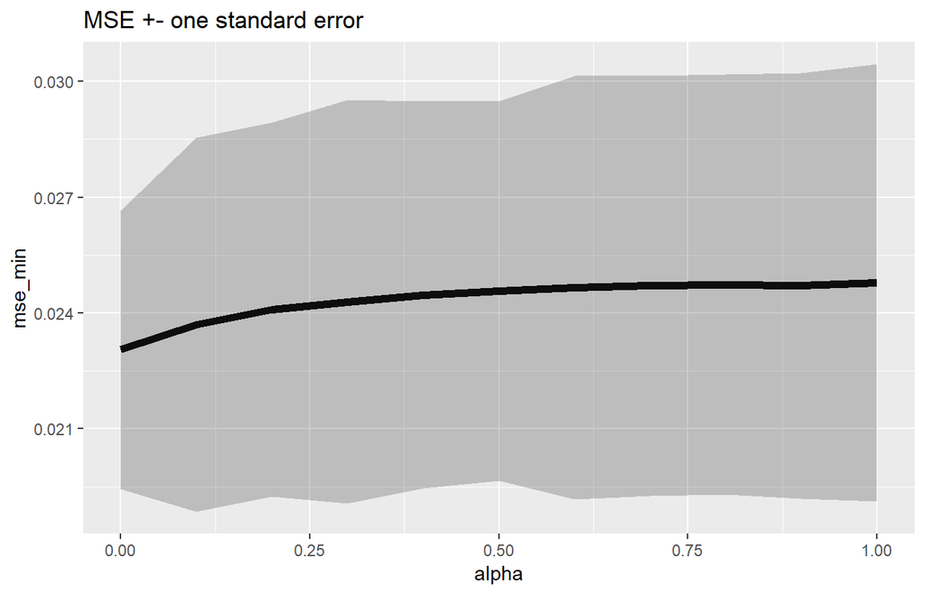

```r
tuning_grid %>%
  mutate(se = mse_1se - mse_min) %>%
  ggplot(aes(alpha, mse_min))+
  geom_line(size = 2)+
  geom_ribbon(aes(ymax = mse_min + se, ymin = mse_min - se), alpha= .25)+
  ggtitle("MSE +- one standard error")
```

**Advantage & Disadvantage**

As previously stated, the advantage of the elastic net model is that it enables effective regularization via the ridge penalty with the feature selection characteristics of the lasso penalty. Effectively, elastic nets allow us to control multicollinearity concerns, perform regression when $p>n$, and reduce excessive noise in our data so that we can isolate the most influential variables while balancing prediction accuracy.

However, elastic nets, and regularization models in general, still assume linear relationships between the features and the target variable. And although we can incorporate non-additive models with interactions, doing this when the number of features is large is extremely tedious and difficult. When non-linear relationships exist, its beneficial to start exploring non-linear regression

#### 2.1.6.7 Predicting

Once you have identified your preferred model, you can simply use `predict` to predict the same model on a new data set. The only caveat is you need to supply `predict` an `s` parameter with the preferred models $\lambda$ value. For example, here we create a lasso model, which provides me a minimum MSE of 0.022. I use the minimum $\lambda$ value to predict on the unseen test set and obtain a slightly lower MSE of 0.015.

```r
# some best model
cv_lasso   <- cv.glmnet(ames_train_x, ames_train_y, alpha = 1.0)
min(cv_lasso$cvm)
```

```
## [1] 0.02276229
## [1] 0.02279668
```

```r
# predict
pred <- predict(cv_lasso, s = cv_lasso$lambda.min, ames_test_x)
mean((ames_test_y - pred)^2)
```

```
## [1] 0.01482233
## [1] 0.01488605
```

#### 2.1.6.8 Other package implementation {##RR_pck_imp}

```r
## caret package
library(caret)

train_control <- trainControl(method = "cv", number = 10)

caret_mod <- train(
  x = ames_train_x,
  y = ames_train_y,
  method = "glmnet",
  preProc = c("center", "scale", "zv", "nzv"),
  trControl = train_control,
  tuneLength = 10
)

caret_mod
## glmnet
##
## 2054 samples
##  307 predictor
##
## Pre-processing: centered (116), scaled (116), remove (191)
## Resampling: Cross-Validated (10 fold)
## Summary of sample sizes: 1848, 1849, 1849, 1848, 1850, 1849, ...
## Resampling results across tuning parameters:
##
##   alpha  lambda        RMSE       Rsquared   MAE
##   0.1    0.0001289530  0.1664866  0.8400298  0.1063403
##   0.1    0.0002978982  0.1664766  0.8400476  0.1063330
##   0.1    0.0006881835  0.1662662  0.8403949  0.1061256
##   0.1    0.0015897932  0.1659395  0.8408804  0.1058245
##   0.1    0.0036726286  0.1654464  0.8415077  0.1053447
##   0.1    0.0084842486  0.1648434  0.8421459  0.1048124
##   0.1    0.0195997152  0.1647791  0.8419495  0.1048721
##   0.1    0.0452778853  0.1669705  0.8382595  0.1066460
##   0.1    0.1045977903  0.1729539  0.8303204  0.1108272
##   0.1    0.2416344679  0.1878788  0.8164867  0.1221649
##   0.2    0.0001289530  0.1665591  0.8399011  0.1063765
##   0.2    0.0002978982  0.1664381  0.8401135  0.1062695
##   0.2    0.0006881835  0.1661633  0.8405549  0.1059868
##   0.2    0.0015897932  0.1657588  0.8411091  0.1055838
##   0.2    0.0036726286  0.1653218  0.8415333  0.1051104
##   0.2    0.0084842486  0.1648215  0.8420818  0.1046553
##   0.2    0.0195997152  0.1666587  0.8388026  0.1061431
##   0.2    0.0452778853  0.1707042  0.8328757  0.1089282
##   0.2    0.1045977903  0.1821489  0.8187373  0.1176380
##   0.2    0.2416344679  0.2091954  0.7990856  0.1393818
##   0.3    0.0001289530  0.1665484  0.8399260  0.1063704
##   0.3    0.0002978982  0.1663784  0.8402128  0.1061899
##   0.3    0.0006881835  0.1661070  0.8406243  0.1058829
##   0.3    0.0015897932  0.1656764  0.8411536  0.1054217
##   0.3    0.0036726286  0.1651358  0.8417307  0.1049183
##   0.3    0.0084842486  0.1653723  0.8411430  0.1050099
##   0.3    0.0195997152  0.1679700  0.8368563  0.1069692
##   0.3    0.0452778853  0.1755597  0.8252335  0.1122168
##   0.3    0.1045977903  0.1904787  0.8103609  0.1239079
##   0.3    0.2416344679  0.2302352  0.7840755  0.1569147
##   0.4    0.0001289530  0.1665065  0.8400056  0.1063544
##   0.4    0.0002978982  0.1663331  0.8402840  0.1061269
##   0.4    0.0006881835  0.1660470  0.8406844  0.1057938
##   0.4    0.0015897932  0.1656703  0.8410583  0.1053616
##   0.4    0.0036726286  0.1650394  0.8418358  0.1047845
##   0.4    0.0084842486  0.1662166  0.8396981  0.1056030
##   0.4    0.0195997152  0.1694620  0.8346366  0.1077863
##   0.4    0.0452778853  0.1789310  0.8210041  0.1147453
##   0.4    0.1045977903  0.1989699  0.8021177  0.1305034
##   0.4    0.2416344679  0.2498300  0.7749964  0.1739895
##   0.5    0.0001289530  0.1665251  0.8399674  0.1063272
##   0.5    0.0002978982  0.1663094  0.8403164  0.1060869
##   0.5    0.0006881835  0.1659512  0.8408118  0.1057081
##   0.5    0.0015897932  0.1655920  0.8411112  0.1053016
##   0.5    0.0036726286  0.1650276  0.8418406  0.1047203
##   0.5    0.0084842486  0.1669364  0.8385065  0.1062020
##   0.5    0.0195997152  0.1712329  0.8318191  0.1088621
##   0.5    0.0452778853  0.1820460  0.8174638  0.1170709
##   0.5    0.1045977903  0.2074241  0.7942057  0.1375506
##   0.5    0.2416344679  0.2701013  0.7651725  0.1926694
##   0.6    0.0001289530  0.1665022  0.8400060  0.1063019
##   0.6    0.0002978982  0.1662639  0.8403902  0.1060353
##   0.6    0.0006881835  0.1659009  0.8408580  0.1056249
##   0.6    0.0015897932  0.1654434  0.8413002  0.1051726
##   0.6    0.0036726286  0.1651883  0.8415612  0.1047942
##   0.6    0.0084842486  0.1673004  0.8379926  0.1064381
##   0.6    0.0195997152  0.1731836  0.8285921  0.1102105
##   0.6    0.0452778853  0.1854054  0.8135735  0.1195101
##   0.6    0.1045977903  0.2154695  0.7870905  0.1441223
##   0.6    0.2416344679  0.2904425  0.7565114  0.2113063
##   0.7    0.0001289530  0.1664774  0.8400472  0.1062793
##   0.7    0.0002978982  0.1662343  0.8404296  0.1059937
##   0.7    0.0006881835  0.1658511  0.8409017  0.1055492
##   0.7    0.0015897932  0.1653171  0.8414810  0.1050438
##   0.7    0.0036726286  0.1654292  0.8411453  0.1049118
##   0.7    0.0084842486  0.1677123  0.8374199  0.1066141
##   0.7    0.0195997152  0.1752421  0.8251856  0.1117240
##   0.7    0.0452778853  0.1890431  0.8091468  0.1221821
##   0.7    0.1045977903  0.2232560  0.7807010  0.1504301
##   0.7    0.2416344679  0.3116026  0.7433510  0.2301070
##   0.8    0.0001289530  0.1664604  0.8400748  0.1062577
##   0.8    0.0002978982  0.1662150  0.8404478  0.1059596
##   0.8    0.0006881835  0.1658293  0.8408901  0.1054960
##   0.8    0.0015897932  0.1652292  0.8416134  0.1049431
##   0.8    0.0036726286  0.1657318  0.8406316  0.1051041
##   0.8    0.0084842486  0.1682919  0.8365325  0.1068928
##   0.8    0.0195997152  0.1768488  0.8228040  0.1129889
##   0.8    0.0452778853  0.1926852  0.8045432  0.1249311
##   0.8    0.1045977903  0.2308092  0.7752165  0.1568161
##   0.8    0.2416344679  0.3341915  0.7100314  0.2497551
##   0.9    0.0001289530  0.1664339  0.8401196  0.1062287
##   0.9    0.0002978982  0.1661987  0.8404598  0.1059166
##   0.9    0.0006881835  0.1658215  0.8408530  0.1054590
##   0.9    0.0015897932  0.1651400  0.8417439  0.1048536
##   0.9    0.0036726286  0.1660693  0.8400605  0.1053749
##   0.9    0.0084842486  0.1690284  0.8353463  0.1073076
##   0.9    0.0195997152  0.1781585  0.8210692  0.1140220
##   0.9    0.0452778853  0.1963207  0.7999649  0.1278744
##   0.9    0.1045977903  0.2384731  0.7698806  0.1636396
##   0.9    0.2416344679  0.3563314  0.6643320  0.2691265
##   1.0    0.0001289530  0.1664021  0.8401715  0.1061981
##   1.0    0.0002978982  0.1661362  0.8405506  0.1058574
##   1.0    0.0006881835  0.1657596  0.8409121  0.1054111
##   1.0    0.0015897932  0.1650751  0.8418319  0.1047814
##   1.0    0.0036726286  0.1663932  0.8395074  0.1056728
##   1.0    0.0084842486  0.1698205  0.8340396  0.1077845
##   1.0    0.0195997152  0.1794887  0.8193334  0.1150336
##   1.0    0.0452778853  0.1999752  0.7952992  0.1308831
##   1.0    0.1045977903  0.2463384  0.7639971  0.1707205
##   1.0    0.2416344679  0.3776853  0.6118306  0.2879720
##
## RMSE was used to select the optimal model using the smallest value.
## The final values used for the model were alpha = 0.1 and lambda
##  = 0.01959972.
```